# Tidyverse

Rockefeller University, Bioinformatics Resource Centre

https://rockefelleruniversity.github.io/Intermediate_R/

These exercises cover the sections of [tidyverse session](https://rockefelleruniversity.github.io/Intermediate_R/).

1. Load in the tidyverse. Read in the fish ecology data in the csv file *exercises_fish.csv*, within the **data** directory. Read the file in again a second time but update the data types to reflect what they are i.e. 2 factors, an integer and a double. Save it as a variable called *fish_df*.

```
## # A tibble: 194 × 4
##    salmon_id `common_name-size`                  variable   value
##        <dbl> <chr>                               <chr>      <dbl>
##  1     35032 Chinook salmon - yearling           length_mm  147
##  2     35032 Chinook salmon - yearling           IGF1_ng_ml  41.3
##  3     35033 Chinook salmon - mixed age juvenile length_mm  444
##  4     35033 Chinook salmon - mixed age juvenile IGF1_ng_ml  62.1
##  5     35034 Sockeye salmon - juvenile           length_mm  139
##  6     35034 Sockeye salmon - juvenile           IGF1_ng_ml  NA
##  7     35035 Sockeye salmon - juvenile           length_mm  121
##  8     35035 Sockeye salmon - juvenile           IGF1_ng_ml  NA
##  9     35036 Sockeye salmon - juvenile           length_mm  112
## 10     35036 Sockeye salmon - juvenile           IGF1_ng_ml  NA
## # ℹ 184 more rows
```

```
## # A tibble: 194 × 4
##    salmon_id `common_name-size`                  variable   value
##        <int> <fct>                               <fct>      <dbl>
##  1     35032 Chinook salmon - yearling           length_mm  147
##  2     35032 Chinook salmon - yearling           IGF1_ng_ml  41.3
##  3     35033 Chinook salmon - mixed age juvenile length_mm  444
##  4     35033 Chinook salmon - mixed age juvenile IGF1_ng_ml  62.1
##  5     35034 Sockeye salmon - juvenile           length_mm  139
##  6     35034 Sockeye salmon - juvenile           IGF1_ng_ml  NA
##  7     35035 Sockeye salmon - juvenile           length_mm  121
##  8     35035 Sockeye salmon - juvenile           IGF1_ng_ml  NA
##  9     35036 Sockeye salmon - juvenile           length_mm  112
## 10     35036 Sockeye salmon - juvenile           IGF1_ng_ml  NA
## # ℹ 184 more rows
```

2. Tidy fish_df using pipes to link everything together. Update fish_df with this tidied dataframe.
3. From your tidied fish_df create a dataframe with the variables *age* and *IGF* for only the *Steelhead* fish

```
## # A tibble: 38 × 2
##    age      IGF1_ng_ml
##    <chr>         <dbl>
##  1 juvenile      42.7
##  2 juvenile      NA
##  3 juvenile       9.92
##  4 juvenile      38.1
##  5 juvenile      46.4
##  6 juvenile      42.6
##  7 juvenile      23.6
##  8 juvenile       4.46
##  9 juvenile      NA
## 10 juvenile      24.2
## # ℹ 28 more rows
```

4. From your tidied fish_df create a dataframe with all the variables except the *IGF* values, for all fish that begin with *S*. Arrange the dataframe based on common_name and length (largest first).

```
## # A tibble: 49 × 4
##    salmon_id common_name    age      length_mm
##        <int> <chr>          <chr>        <dbl>
##  1     35144 Sockeye salmon juvenile       140
##  2     35034 Sockeye salmon juvenile       139
##  3     35119 Sockeye salmon juvenile       122
##  4     35035 Sockeye salmon juvenile       121
##  5     35100 Sockeye salmon juvenile       118
##  6     35096 Sockeye salmon juvenile       115
##  7     35147 Sockeye salmon juvenile       115
##  8     35036 Sockeye salmon juvenile       112
##  9     35098 Sockeye salmon juvenile       112
## 10     35099 Sockeye salmon juvenile       111
## # ℹ 39 more rows
```

6. From your tidied fish_df perform these steps using a pipe:
- Group by the variable *age*.
- Filter to get the biggest 5 by the variable *length* in each group.
- Summarize this data frame over the variable *length* by calculating the mean.

```r
fish_df %>%
  group_by( age) %>%
  filter(rank(-length_mm) <= 5) %>%
  summarise( mean_length_mm = mean(length_mm, na.rm = T))
```

```
## # A tibble: 4 × 2
##   age                mean_length_mm
##   <chr>                       <dbl>
## 1 juvenile                     274
## 2 mixed age juvenile           380.
## 3 subyearling                   90
## 4 yearling                     213
```

7. From your tidied fish_df perform these steps using a pipe:
- Filter to only look at *yearling* in variable age
- Group by common_name
- Create new variable that is z-score of *length* across groups (HINT: The *scale()* function can be used to calculate z-scores)
- Create boxplot of grouped length z-scores

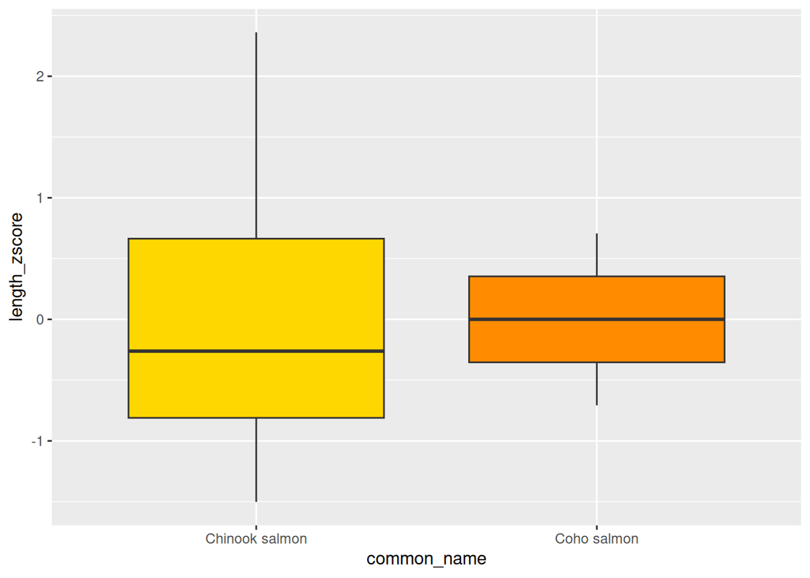

8. Read in the count data *tidy_counts.csv* from the **data** directory. Try setting different data types i.e. factors and logicals. What happens when we extract the vector of these counts? Data types are coerced if the wrong data types are specified.

```
## [1] "350" "350" "350" "350" "351" "351" "351" "351"
```

```
## [1] "307"   "307"   "307"   "307"   "26580" "26580" "26580" "26580"
```

```
## [1] TRUE TRUE   NA   NA TRUE TRUE   NA   NA
```

9. Re-read the tidy counts CSV into R. How many ATPase genes (starting with ATP) are there and what are they? Subset dataframe to just these ATPase genes. Create a new lowercase variable that has ‘ATP’ removed from the symbol.

## Load in dataset and packages

[output not shown]

```
##  [1] "ATP1A1" "ATP1A2" "ATP1A3" "ATP12A" "ATP1A4" "ATP1B1" "ATP1B2" "ATP1B3"
##  [9] "ATP2A1" "ATP2A2" "ATP2A3" "ATP2B1" "ATP2B2" "ATP2B3" "ATP2B4"
```

```
## # A tibble: 60 × 12
##    ENTREZ Sample  CellType   Rep counts count_total     CPM SYMBOL CHR   LENGTH
##     <dbl> <chr>   <chr>    <dbl>  <dbl>       <dbl>   <dbl> <chr>  <chr>  <dbl>
##  1    476 CD34_1  CD34         1   4952       14023 33065.  ATP1A1 chr1    5912
##  2    476 ORTHO_1 ORTHO        1   3453       14023 41990.  ATP1A1 chr1    5912
##  3    476 CD34_2  CD34         2   4202       14023 39760.  ATP1A1 chr1    5912
##  4    476 ORTHO_2 ORTHO        2   1416       14023 43033.  ATP1A1 chr1    5912
##  5    477 CD34_1  CD34         1     13          44    86.8 ATP1A2 chr1    5972
##  6    477 ORTHO_1 ORTHO        1      3          44    36.5 ATP1A2 chr1    5972
##  7    477 CD34_2  CD34         2     26          44   246.  ATP1A2 chr1    5972
##  8    477 ORTHO_2 ORTHO        2      2          44    60.8 ATP1A2 chr1    5972
##  9    478 CD34_1  CD34         1     78         266   521.  ATP1A3 chr19   4054
## 10    478 ORTHO_1 ORTHO        1    121         266  1471.  ATP1A3 chr19   4054
## # ℹ 50 more rows
## # ℹ 2 more variables: TPM <dbl>, ATPtype <chr>
```